# Проверка гипотез. Классические статистические тесты

Jelena Čuklina & Maria Chernigovskaya & Alexey Glazkov

Октябрь 2025

# Настройка

```r
library(dplyr)
library(ggplot2)
library(epitools)
# Предполагаем, что используется пакет NHANES для получения набора данных
library(NHANES)
library(tidyr)
```

В этом упражнении мы будем использовать набор данных NHANES (Национальное обследование здоровья и питания), который доступен через пакет NHANES. Эти данные содержат информацию о здоровье и питании населения США и широко используются для статистического анализа в области здравоохранения.

Подробное описание данных можно найти тут: https://cran.r-project.org/web/packages/NHANES/NHANES.pdf

```r
# Загрузка набора данных NHANES (из пакета NHANES)
data(NHANES)
```

Подготовка чистого набора данных для анализа

```r
# Фокус на ключевых переменных для упражнения
nhanes_clean <- NHANES %>%
  select(Gender, Age, BMI, Diabetes, BPSysAve, BPDiaAve, PhysActive, SleepTrouble, Height, Weight, Education, HHIncome) %>%
  # Удаление строк с отсутствующими данными для упрощения в этих упражнениях
  na.omit() %>%
  # Фильтрация для возраста >= 18 для исследований взрослых
  filter(Age >= 18)

# Проверка структуры данных для студентов
cat("Структура чистого набора данных NHANES (взрослые, >=18 лет):\n")
```

```
## Структура чистого набора данных NHANES (взрослые, >=18 лет):
```

```r
str(nhanes_clean)
```

```
## tibble [6,346 × 12] (S3: tbl_df/tbl/data.frame)
##  $ Gender      : Factor w/ 2 levels "female","male": 2 2 2 1 1 1 1 2 2 2 ...
##  $ Age         : int [1:6346] 34 34 34 49 45 45 45 66 58 54 ...
##  $ BMI         : num [1:6346] 32.2 32.2 32.2 30.6 27.2 ...
##  $ Diabetes    : Factor w/ 2 levels "No","Yes": 1 1 1 1 1 1 1 1 1 1 ...
##  $ BPSysAve    : int [1:6346] 113 113 113 112 118 118 118 111 104 134 ...
##  $ BPDiaAve    : int [1:6346] 85 85 85 75 64 64 64 63 74 85 ...
##  $ PhysActive  : Factor w/ 2 levels "No","Yes": 1 1 1 1 2 2 2 2 2 2 ...
##  $ SleepTrouble: Factor w/ 2 levels "No","Yes": 2 2 2 2 1 1 1 1 1 2 ...
##  $ Height      : num [1:6346] 165 165 165 168 167 ...
##  $ Weight      : num [1:6346] 87.4 87.4 87.4 86.7 75.7 75.7 75.7 68 78.4 74.7 ...
##  $ Education   : Factor w/ 5 levels "8th Grade","9 - 11th Grade",..: 3 3 3 4 5 5 5 4 5 2 ...
##  $ HHIncome    : Factor w/ 12 levels " 0-4999"," 5000-9999",..: 6 6 6 7 11 11 11 6 12 10 ...
##  - attr(*, "na.action")= 'omit' Named int [1:3654] 4 6 7 14 17 20 23 27 35 38 ...
##   ..- attr(*, "names")= chr [1:3654] "4" "6" "7" "14" ...
```

# Тесты для непрерывных данных

## Параметрические тесты

### 1: сравнение ИМТ с историческим средним

На основе исторических данных среднее значение ИМТ (BMI) для взрослых в США составляет **28.5**. ИМТ (индекс массы тела) рассчитывается как масса в килограммах, делённая на квадрат роста в метрах: BMI = weight (kg) / height (m)^2. Вопрос исследования: отличается ли среднее значение ИМТ в популяции взрослых (возраст ≥ 18) от исторического значения **28.5**?

#### Задания:

##### Задание 1.1

Сформурируйте нулевую гипотезу и альтернативную гипотезу

- $H_0$: *Среднее значение ИМТ в выборке равно 28.5*
- $H_a$: *Среднее значение ИМТ в выборке больше или меньше 28.5*

##### Задание 1.2

Посчитайте ключевые статистики (среднее, стандартное отклонение, размер выборки) для переменной BMI в вашем чистом наборе данных `nhanes_clean`.

```r
# Расчет ключевых статистик для BMI
mean_bmi = mean(nhanes_clean$BMI) # Среднее значение BMI

sd_bmi = sd(nhanes_clean$BMI) # Стандартное отклонение BMI

n_bmi = length(nhanes_clean$BMI) # размер выборки BMI
```

##### Задание 1.3

Выберите подходящий статистический тест для проверки гипотез из задания 1.1 и объясните свой выбор.

*Одновыборочный двухсторонний t-test. Группа у нас только одна, сравниваем с историческим значением. Направление эффекта заранее не знаем, поэтому тест двухсторонний.*

##### Задание 1.4

Используя выбранный тест, проверьте гипотезы из задания 1.1 на уровне значимости α = 0.1.

```r
#
mu_0_bmi <- 28.5

# Выполнение теста
test_BMI <-  t.test(
  x = nhanes_clean$BMI,
  mu = mu_0_bmi,
  alternative = "two.sided",
  conf.level = 0.9
)

print(test_BMI)
```

```
##
##  One Sample t-test
##
## data:  nhanes_clean$BMI
## t = 4.345, df = 6345, p-value = 1.414e-05
## alternative hypothesis: true mean is not equal to 28.5
## 90 percent confidence interval:
##  28.72641 29.00232
## sample estimates:
## mean of x
##  28.86437
```

##### Задание 1.5

Как p-значение и 90% доверительный интервал информируют вас об общем статусе ИМТ этой популяции относительно среднего значения в общей популяции в 28.5? Что вы можете сказать про статистическую значимость?

*90% CI (28.7; 29.0) говорит о том, что с вероятностью 90% истинное значение ИМТ в исследуемой популяции находится в данной интервале. Данный CI не захватывает исторической значение 28.5. p-value = 1.414e-05 указывает на статистически значимый результат (разницу среднего ИМТ в популяции и исторического значения). Следовательно, можно отвергнуть нулевую гипотезу о том, что среднее значение ИМТ в выборке равно 28.5*

### 2. Сравнение давления у мужчин и женщин

Сценарий: Исследователи хотят сравнить систолическое артериальное давление у мужчин и женщин. Вопрос исследования: Есть ли статистически значимая разница в среднем систолическом артериальном давлении ($\mathbf{BPSysAve}$) между **мужчинами** и **женщинами**?

##### Задание 2.1

Сформулируйте нулевую и альтернативную гипотезы

- $H_0$: *Среднее систолическое давление в группе мужчин не отличается от среднего систолическое давления в группе женщин*
- $H_a$: *Средние значения систолическое давления для мужчин и женщин отличаются*

Подумайте, имеет ли значение, в какой группе давление больше

##### Задание 2.2

Посчитайте ключевые статистики (среднее в каждой группе, стандартное отклонение, размер каждой группы) для переменной `BPSysAve` в вашем чистом наборе данных `nhanes_clean`. Группы определяются переменной `Gender`.

```r
####### Давление у мужчин ######

nhanes_clean_male <- nhanes_clean %>%
  filter(Gender == 'male') %>% # Убираем нулевые значения ИМТ (вероятно, пропущенные данные)
  drop_na()

# Расчет ключевых статистик для BPSysAve в группе мужчин

mean_BPSysAve_male = mean(nhanes_clean_male$BPSysAve) # Среднее значение BPSysAve

sd_BPSysAve_male = sd(nhanes_clean_male$BPSysAve) # Стандартное отклонение BPSysAve

n_BPSysAve_male = length(nhanes_clean_male$BPSysAve) # размер выборки BPSysAve

####### Давление у женщин ######

nhanes_clean_female <- nhanes_clean %>%
  filter(Gender == 'female') %>% # Убираем нулевые значения ИМТ (вероятно, пропущенные данные)
  drop_na()

# Расчет ключевых статистик для BPSysAve в группе мужчин

mean_BPSysAve_female = mean(nhanes_clean_female$BPSysAve) # Среднее значение BPSysAve

sd_BPSysAve_female = sd(nhanes_clean_female$BPSysAve) # Стандартное отклонение BPSysAve

n_BPSysAve_female = length(nhanes_clean_female$BPSysAve) # размер выборки BPSysAve
```

##### **Задание 2.3**

Выберите подходящий статистический тест для проверки гипотез из задания 2.1 и объясните свой выбор.

*Независимый односторонний t-test. По рассчитанным значениям mean известно, что в группе ‘male’ среднее значение систолического давления больше, чем в группе ‘female’. Выборки незаисимы.*

##### **Задание 2.4**

Используя выбранный тест, проверьте гипотезы из задания 2.1 на уровне значимости α = 0.1.

```r
# Выполнение теста

test_BPSysAve <- t.test(BPSysAve ~ Gender, data = nhanes_clean,  alternative = "less", var.equal = FALSE, conf.level = 0.9) # var.equal = FALSE использует поправку Уэлча (рекомендуется)

print(test_BPSysAve)
```

```
##
##  Welch Two Sample t-test
##
## data:  BPSysAve by Gender
## t = -9.3476, df = 6252.6, p-value < 2.2e-16
## alternative hypothesis: true difference in means between group female and group male is less than 0
## 90 percent confidence interval:
##       -Inf -3.391404
## sample estimates:
## mean in group female   mean in group male
##             118.9586             122.8889
```

##### Задание 2.5

Как p-значение и 90% доверительный интервал информируют вас о разнице измеренного артериального давления между мужчинами и женщинами? Что вы можете сказать про статистическую значимость?

**Ответ:**

1. **Статистическая значимость**: p-value < 2.2e-16 (крайне малое значение) свидетельствует о статистически значимом различии между средними значениями систолического давления у мужчин и женщин.
2. **Направление и размер эффекта**:
   - Среднее значение систолического давления **у мужчин**: 122.8 мм рт. ст.
   - Среднее значение систолического давления **у женщин**: 118.9 мм рт. ст.
   - **Разность средних**: 122.8 - 118.9 = **3.9 мм рт. ст.** (мужчины имеют большее среднее значение систолического давления)
3. **t-статистика**: t = -9.3476 (отрицательное значение указывает на то, что первая группа ‘female’ имеет меньшее среднее значение, чем вторая группа ‘male’)
4. **Доверительный интервал**: 90% доверительный интервал для разности средних составляет [-Inf: -3.39], что означает, что с вероятностью 90% истинная разница средних находится в данном интервале (отрицательные значения указывают на то, что группа ‘female’ имеет меньшие значения, чем группа ‘male’).

**Заключение**: Существует статистически значимая разница между мужчинами и женщинами в средних значениях систологического давления.

### 3: Сравнение систолического и диастолического давления

Сценарий: Измерения систолического ($\mathbf{BPSysAve}$) и диастолического ($\mathbf{BPDiaAve}$) давления не являются независимыми. Вопрос исследования: Равна ли нулю средняя **разница** между систолическим ($\mathbf{BPSysAve}$) и диастолическим ($\mathbf{BPDiaAve}$) давлением (пульсовое давление) в исследуемой популяции?

##### Задание 3.1

Сформулируйте нулевую и альтернативную гипотезы

- $H_0$: *Средняя разность между систоличеким и диастолическим давлением равно нулю*
- $H_a$: *Средняя разность между систоличеким и диастолическим давлением не равно нулю*

Подумайте, имеет ли значение, в какой группе давление больше

##### Задание 3.2

Посчитайте ключевые статистики для переменной `BPSysAve` и `BPDiaAve` в вашем чистом наборе данных `nhanes_clean`.

```r
# Расчет ключевых статистик для систолического давления (BPSysAve)

mean_BPSysAve = mean(nhanes_clean$BPSysAve) # Среднее значение BPSysAve

sd_BPSysAve = sd(nhanes_clean$BPSysAve) # Стандартное отклонение BPSysAve

n_BPSysAve = length(nhanes_clean$BPSysAve) # размер выборки BPSysAve

# Расчет ключевых статистик для диастолического давления (BPDiaAve)

mean_BPDiaAve = mean(nhanes_clean$BPDiaAve) # Среднее значение BPDiaAve

sd_BPDiaAve = sd(nhanes_clean$BPDiaAve) # Стандартное отклонение BPDiaAve

n_BPDiaAve = length(nhanes_clean$BPDiaAve) # размер выборки BPDiaAve
```

**Дополнительно (необязательное задание)** Визуализируйте эти параметры. Используйте боксплот, свяжите линиями измерения одного пациента.

##### Задание 3.3

Выберите подходящий статистический тест для проверки гипотез из задания 3.1 и объясните свой выбор.

*Односторонний парный t-test. Т.к. группы зависимы (измерения одного человека), а по рассчитанным значениям mean известно, что средние между группами различаются, причем среднее в группе BPSysAve больше чем среднее в группе BPDiaAve*

##### Задание 3.4

Используя выбранный тест, проверьте гипотезы из задания 3.1 на уровне значимости α = 0.1.

```r
# paired = TRUE указывает, что измерения парные

test_BP <- t.test(nhanes_clean$BPSysAve, nhanes_clean$BPDiaAve, paired = TRUE, alternative = "greater", conf.level = 0.9)

print(test_BP)
```

```
##
##  Paired t-test
##
## data:  nhanes_clean$BPSysAve and nhanes_clean$BPDiaAve
## t = 234.32, df = 6345, p-value < 2.2e-16
## alternative hypothesis: true mean difference is greater than 0
## 90 percent confidence interval:
##  50.27769      Inf
## sample estimates:
## mean difference
##        50.55421
```

##### Задание 3.5

Как p-значение и 90% доверительный интервал информируют вас о разнице измеренного систолического и диастолического артериального давления? Что вы можете сказать про статистическую значимость?

**Ответ:**

1. **Статистическая значимость**: p-value < 2.2e-16 (крайне малое значение) свидетельствует о статистически значимом различии между средними значениями систолического и диастолического давления.
2. **Направление и размер эффекта**:
   - **Разность средних**: **50.55421** (систолическое давление больше диастолического)
3. **t-статистика**: t = 234.32
4. **Доверительный интервал**: 90% доверительный интервал для разности средних составляет [50.27769; Inf], что означает, что с вероятностью 90% истинная разница средних находится в данном интервале.

**Заключение**: Существует статистически значимая разница между средними значениями систолического и диастолического давления.

## Непараметрические тесты

Допустим, мы хотим сравнить статистическое доминирование ИМТ, а не средние абсолютные значения

### 4: Сравнение ИМТ мужчин и женщин при помощи непараметрических тестов

Вопрос исследования: Отличаются ли превосходят ли как правило ИМТ ($\mathbf{BMI}$) у представителей одного пола относительно другого?

##### Задание 4.1

Сформулируйте нулевую и альтернативную гипотезы

$H_0$: *Распределение ИМТ одинаково для мужчин и женщин*

$H_a$: *Есть разница между рангами ИТМ между мужчинами и женщинами*

##### Задание 4.2

Посчитайте ключевые статистики (количество пациентов в каждой группе и другие статистики по необходимости)

```r
length(nhanes_clean_male$Gender) # количество мужчин
```

```
## [1] 3159
```

```r
length(nhanes_clean_female$Gender) # количество женщин
```

```
## [1] 3187
```

Объясните, почему выбор статистик отличается для этого сценария от сценариев 1, 2 и 3.

*Для подсчета ранга необходимо только количество наблюдений в каждой из групп и значения этих наблюдений*

##### Задание 4.3

Обоснуйте, является ли тест Манна-Уитни подходящим для проверки гипотез из задания 4.1 и объясните свой выбор.

Имеет ли значение для выбора теста, сколько пациентов в каждой группе? Что, если бы в одной группе было бы 10 пациентов или меньше? А если 2 пациента?

Являются ли группы зависимыми или независимыми?

*Исследователю интересно статистическое доминирование ИМТ, а не средние абсолютные значения. Т.е. превосходят ли как правильно значения в одной группе значения из другой группы. Для этого нужно использовать ранги, а значит, нужно использовать критерий Манна-Уитни (выборки независимы). Количество наблюдений в группах должно быть примерно одинаковым, иначе тест Манна-Уитни покажет искаженный результат (значения из одной группы будут попадаться чаще, чем из другой). Тест Манна-Уитни подходит для малых выборок, желательно от 3 наблюдений в каждой группе. Допускается, чтобы в одной выборке было 2 значения, но во второй тогда должно быть не менее пяти.* [1]: https://medstatistic.ru/methods/methods2.html

##### Задание 4.4

Проверьте гипотезы из задания 4.1 на уровне значимости α = 0.1.

```r
bmi_gender_test <- wilcox.test(BMI ~ Gender,
  data = nhanes_clean,
  alternative = "less",
  conf.level = 0.9,
  conf.int = TRUE
)

print(bmi_gender_test)
```

```
##
##  Wilcoxon rank sum test with continuity correction
##
## data:  BMI by Gender
## W = 4701995, p-value = 2.709e-06
## alternative hypothesis: true location shift is less than 0
## 90 percent confidence interval:
##        -Inf -0.4999927
## sample estimates:
## difference in location
##             -0.6999872
```

##### Задание 4.5

Как p-значение и 90% доверительный интервал информируют вас разнице между группами? Что вы можете сказать про статистическую значимость?

*Ответ:* p-value = 2.709e-06, что говорит о статистически значимом различии между значениями ИМТ у мужчин и женщин. 90% ДИ [-Inf; -0.49] говорит о том, что с 90% вероятностью данный интервал накрывает истинное различие в рангах между значениями ИМТ у мужчин и женщин. Отрицательный знак говорит о том, что в первой группе ‘female’ значения рангов меньше, чем во второй группе ‘male’.

### 5 Разница между медианами САД и ДАД

Сценарий: Вопрос исследования: превосходят ли, как правило, значения одного типа артериального давления значения другого типа (САД vs. ДАД)? САД - систолическое артериальное давление, ДАД - диастолическое артериальное давление

##### Задание 5.1

Сформулируйте нулевую и альтернативную гипотезы

- $H_0$: *Распределение различий систолического и диастолического давлений симметрично относительно нуля (нет разницы)*
- $H_a$: *Значения систолического давление стохастически больше чем значения диастолического*

##### Задание 5.2

Посчитайте ключевые статистики для переменной `BPSysAve` и `BPDiaAve` в вашем чистом наборе данных `nhanes_clean`. Обратите внимание, что это иные статистики, чем в задании 3.

```r
nhanes_clean_dif <- nhanes_clean %>%
  mutate(Difference = BPSysAve - BPDiaAve)

nhanes_clean_dif <- nhanes_clean_dif %>%
  select(BPSysAve, BPDiaAve, Difference)

  print(nhanes_clean_dif) # Значения сист. и диаст. давлений и их разницы для каждого пациента
```

```
## # A tibble: 6,346 × 3
##    BPSysAve BPDiaAve Difference
##       <int>    <int>      <int>
##  1      113       85         28
##  2      113       85         28
##  3      113       85         28
##  4      112       75         37
##  5      118       64         54
##  6      118       64         54
##  7      118       64         54
##  8      111       63         48
##  9      104       74         30
## 10      134       85         49
## # ℹ 6,336 more rows
```

**Дополнительно (необязательное задание)** Визуализируйте эти параметры. Используйте violinplot и boxplot, свяжите линиями измерения одного пациента. Визуально оцените, как выглядит распределение обеих переменных

##### Задание 5.3

Выберите подходящий статистический тест для проверки гипотез из задания 5.1 и объясните свой выбор.

*Подходящий тест - критерий Уилкоксона для связанных выборок (или критерий знаковых рангов Уилкоксона). Т.к. задача сравнить в целом тендецию, больше ли значения систолического давления чем диастолического. Т.к. значения в группах зависимы (показатели одного человека), то нужно выбрать тест для связанных выборок.*

##### Задание 5.4

Используя выбранный тест, проверьте гипотезы из задания 5.1 на уровне значимости α = 0.1.

```r
#paired = TRUE указывает, что измерения парные

test_BP <- wilcox.test(
  x = nhanes_clean$BPSysAve,
  y = nhanes_clean$BPDiaAve,
  alternative = "greater", # Проверяем, больше ли До чем После
  paired = TRUE,
  conf.level = 0.9,
  conf.int = TRUE
)


print(test_BP)
```

```
##
##  Wilcoxon signed rank test with continuity correction
##
## data:  nhanes_clean$BPSysAve and nhanes_clean$BPDiaAve
## V = 20139031, p-value < 2.2e-16
## alternative hypothesis: true location shift is greater than 0
## 90 percent confidence interval:
##  48.49997      Inf
## sample estimates:
## (pseudo)median
##       48.50004
```

##### Задание 5.5

Как p-значение и 90% доверительный интервал информируют вас о разнице измеренного систолического и диастолического артериального давления? Что вы можете сказать про статистическую значимость?

*Ответ:* p-value < 2.2e-16, что говорит о статистически значимом различии между значениями систолического и диастолического артериального давления у пациента. 90% ДИ [48.49; Inf] говорит о том, что с 90% вероятностью данный интервал накрывает истинное различие в рангах между значениями значениями систолического и диастолического артериального давления у пациента. ————————————————————————

# Тесты для категориальных данных

### 6: Поиск зависимости между физической активностью и проблемами со сном

Вы хотите исследовать, есть ли взаимосвязь между проблемами со сном у человека и тем, занимается ли он физической активностью. Переменные: $\mathbf{PhysActive}$ — бинарный признак (1 = активно занимается, 0 = не занимается), $\mathbf{SleepTrouble}$ — бинарный признак (1 = есть проблемы со сном, 0 = нет проблем).

#### Задания:

##### Задание 6.1

Сформулируйте нулевую и альтернативную гипотезы для проверки связи между физической активностью и проблемами со сном. Какую альтернативу вы используете — одностороннюю или двустороннюю? Обоснуйте ответ

- $H_0$: *Признаки “физическая активность” и “проблемы со сном” независимы*
- $H_a$: *Признаки “физическая активность” и “проблемы со сном” зависимы*

##### Задание 6.2

Постройте таблицу сопряженности и визуализируйте ее. Исходя из полученной таблицы и иллюстрации, как вам кажется, похожи ли наши признаки на независимые? Почему?

```r
cont_table_2x2 <- table(nhanes_clean$PhysActive, nhanes_clean$SleepTrouble)
print(cont_table_2x2)
```

```
##
##         No  Yes
##   No  2107  821
##   Yes 2538  880
```

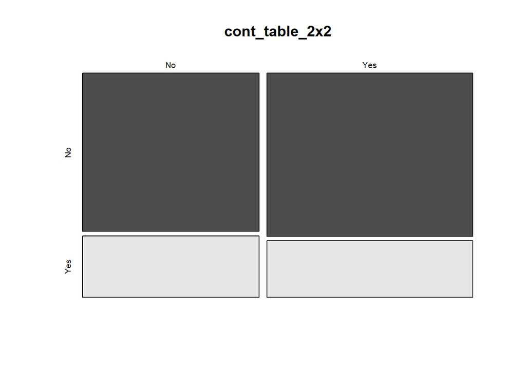

```r
mosaicplot(cont_table_2x2, color=TRUE)
```

Признаки похожи на независимые (данные по строкам и столбцам не сильно различаются)

##### Задание 6.3

Какой статистический тест подходит для тестирования гипотезы из 6.1 (Хи-квадрат, Фишер, МакНемара)? Объясните свой выбор. Какие ограничения у выбранного теста? Если нужно, проверьте ограничения

*Тест Хи-квадрат. Т.к. группы независимы и числа по строкам и столбцам не зафиксированы.*

##### Задание 6.4

Используя выбранный тест, проверьте гипотезы из 6.1 на уровне значимости α = 0.05. Какое p-значение и значение статистики критерия получилось? Что вы можете сказать про статистическую значимость?

Совпадает ли результат статистического анализа с вашим предположением в 6.2? Если нет, попробуйте объяснить почему

```r
chisq_2x2 <- chisq.test(cont_table_2x2, correct = F)
print(chisq_2x2)
```

```
##
##  Pearson's Chi-squared test
##
## data:  cont_table_2x2
## X-squared = 4.2284, df = 1, p-value = 0.03975
```

X-squared = 4.2284, p-value = 0.03975. Следовательно, можно отвергнуть нулевую гипотезу -> признаки зависимы. Это расходится с первоначальным предположением о независимости признаков, из-за визуального равенства групп. И p-value близкое к порогу стат значимости 0,05. А также еще может быть потому, что в тесте Хи-квадрат p-value вычисляется приближенно (по описанию теста в Help и переменной simulate.p.value)

##### Задание 6.5

Посчитайте размер эффекта (отношение шансов и отношение рисков, если это имеет смысл для этого исследования) двумя способами – самостоятельно (посчитайте дроби исходя из таблицы сопряженности), и с помощью пакета epitools, сравните результаты. Проинтерпретируйте результат с точки зрения клинической значимости (не забудьте про 95% доверительный интервал!). Прокомментируйте, почему вы решили считать или не считать отношение рисков.

```r
# сила взаимосвязи (считаем сами)
# PhysActive - SleepTrouble

## Risk Ratio
(2107    / (2107  +821  )) / (2538   / (880+2538  )) # 0.9691118
```

```
## [1] 0.9691118
```

```r
# Odds Ratio
(2107/821) / (2538/880) # 0.889841
```

```
## [1] 0.889841
```

```r
# epitools
riskratio(cont_table_2x2)
```

```
## $data
##
##           No  Yes Total
##   No    2107  821  2928
##   Yes   2538  880  3418
##   Total 4645 1701  6346
##
## $measure
##      risk ratio with 95% C.I.
##        estimate     lower     upper
##   No  1.0000000        NA        NA
##   Yes 0.9182026 0.8465132 0.9959632
##
## $p.value
##      two-sided
##       midp.exact fisher.exact chi.square
##   No          NA           NA         NA
##   Yes  0.0399206   0.04071481 0.03975289
##
## $correction
## [1] FALSE
##
## attr(,"method")
## [1] "Unconditional MLE & normal approximation (Wald) CI"
```

```r
oddsratio(cont_table_2x2)
```

```
## $data
##
##           No  Yes Total
##   No    2107  821  2928
##   Yes   2538  880  3418
##   Total 4645 1701  6346
##
## $measure
##      odds ratio with 95% C.I.
##        estimate     lower     upper
##   No  1.0000000        NA        NA
##   Yes 0.8898525 0.7961661 0.9946383
##
## $p.value
##      two-sided
##       midp.exact fisher.exact chi.square
##   No          NA           NA         NA
##   Yes  0.0399206   0.04071481 0.03975289
##
## $correction
## [1] FALSE
##
## attr(,"method")
## [1] "median-unbiased estimate & mid-p exact CI"
```

Дизайн - поперечное исследование, а значит можно рассчитывать RR (Отношение рисков). RR < 1, 95% ДИ [0.84; 0.99] не захватывает 1, значит риск проблем со сном во второй группе (пациенты с физ. активностью) ниже, чем в группе без физ. активности. OR < 1, 95% ДИ [0.79; 0.99] не захватывает 1, значит шанс проблем со сном во второй группе (пациенты с физ. активностью) ниже, чем в группе без физ. активности.

##### Задание 6.6

Исходя из результатов статистического анализа, можем ли мы сделать вывод, что физическая активность улучшает сон? Или что люди, которые лучше спят, чаще занимаются спортом?

*результаты теста показывают только статистическую взаимосвязь переменных, но не причинно-следственную связь. Поэтому мы не можем сделать вывод, что физ. активность улучшает сон или наоборот.*

# Поиск зависимостей между количественными / порядковыми признаками

### 7. Анализ зависимости между ростом и массой тела

Вопрос. Есть ли линейная связь между ростом (Height) и весом (Weight) у участников NHANES старше 18 лет?

#### Задание 7.1

Сформулируйте нулевую и альтернативную гипотезы.

- $H_0$: Между ростом и весом нет линейной связи. (Или коэффициент корреляции равен 0)
- $H_a$: Рост и вес связаны линейно. (Или коэффициент корреляции не равен 0)

#### Задание 7.2

Визуализируйте распределения анализируемых переменных. Визуально оцените форму распределений и наличие выбросов.

Постройте диаграмму рассеяния Height vs Weight (график должен быть читаемым), оцените линейность связи признаков.

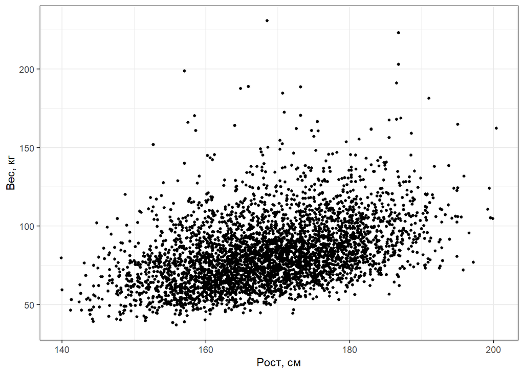

```r
nhanes_clean %>%
    ggplot(aes(x = Height, y = Weight)) +
    geom_point(size = 1.1) +

    # Добавим красивые подписи осей
    labs(x = "Рост, см",
         y = "Вес, кг") +

    # Поменяем оформление графика
    theme_bw()
```

Визуально наблюдается положительная линейная зависимость.

#### Задание 7.3

Выберите подходящий статистический тест для проверки гипотезы из п. 7.1 и объясните свой выбор.

Используя выбранный тест, проверьте гипотезы из п. 7.1 на уровне значимости α = 0.05.

Оцените величину наблюдаемого эффекта.

```r
cor.test(nhanes_clean$Height,
         nhanes_clean$Weight)
```

```
##
##  Pearson's product-moment correlation
##
## data:  nhanes_clean$Height and nhanes_clean$Weight
## t = 40.198, df = 6344, p-value < 2.2e-16
## alternative hypothesis: true correlation is not equal to 0
## 95 percent confidence interval:
##  0.4307252 0.4699494
## sample estimates:
##       cor
## 0.4505547
```

Выбран тест корреляции Пирсона, т.к. нужно проверить линейную взаимосвязь между признаками. p-value < 2.2e-16, cor= 0.4505547 говорят о статистической значимой линейной зависимости между ростом и весом с коэффициентом корреляции = 0.45, что по шкале Чеддока говорит об умеренной корреляции.

#### Задание 7.4

Как p-значение и 95% доверительный интервал информируют вас о силе и направлении связи между ростом и весом? Что вы можете сказать про статистическую и практическую значимость результата?